# Random graphs and the modelling of social networks

## Abstract

Random graphs are a branch of graph theory in mathematics, and represent graphs created using random processes. These have wide applications, including power grids, food webs, protein networks. Our main focus will however be on the modelling of social networks using random graphs. We shall first look at important properties of random graphs by introducing different models, and compare these with a sample network of Facebook. Finally, this report will introduce a new model devised by the presenter.

## What are Random Graphs?

Random graphs are graphs of nodes or vertices, which are connected by edges. These connections and nodes are generated either by following a random distribution, or a random process.

There are many different models that use different methods to create random graphs, to obtain different graphs with different properties.

## What properties do we want?

Different models are suited for different applications.

In our case, we focus on modelling social networks, thus we will be discussing the common characteristics that these networks display.

## The first model: Erdős–Rényi

The first and simplest of the random graphs.

The first model we will look at is the Erdős–Rényi model. This model requires two parameters, $n$ for the number of nodes, and $p$ for the probability of an edge existing between any two nodes independently. The expected total number of edges is therefore $p \times {n \choose 2}$, as ${n \choose 2}$ is the total possible number of edges that can be formed.

[figure not shown]

```python
n = 50
p = 0.1

g = erdos_renyi(n, p)
pos = nx.get_node_attributes(g, 'pos')
nx.draw(g, pos)
```

## Clustering

A commonly studied property of random graphs is the clustering coefficient. This is a measure to quantify how likely it is that, if you know two friends, the two of them would know each other.

Local clustering coefficient is the clustering coefficient for a specific node, and is calculated as the no. of existing edges between neighbouring nodes divided by the no. of potential edges between neighbouring nodes.

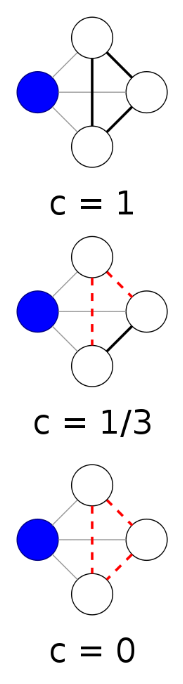

## It's a Small World

Researches often say that we live in a small world. This means that we can reach out to almost anyone in the world with just a few connections, famously known as the six degrees of separation.